# A study of red wine

# Bivariate Plots Section

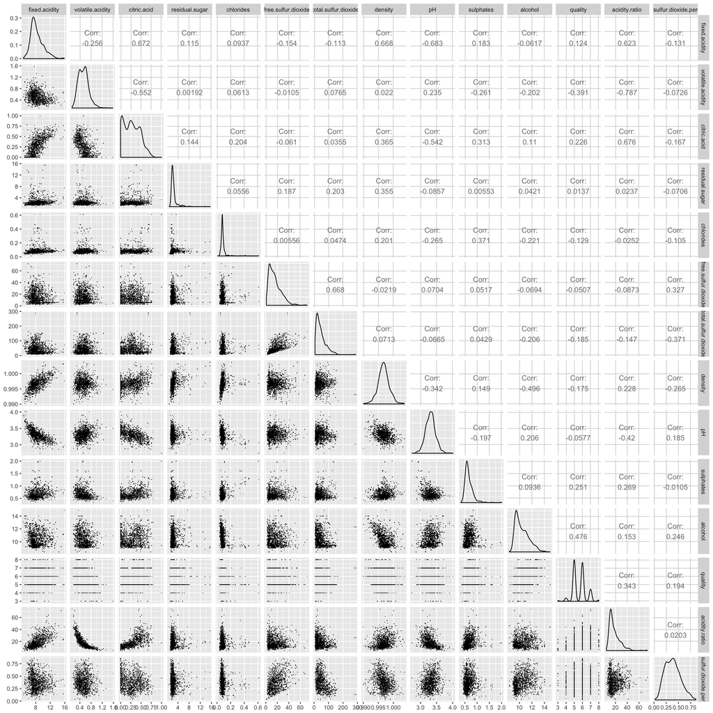

# Bivariate Analysis

### Talk about some of the relationships you observed in this part of the investigation. How did the feature(s) of interest vary with other features in the dataset?

from the plot above it can be seen that there are variables possibly have strong relationship with others. For example, the fixed.acidity have a positive relation with citric acidity and the volatile acidity have negative relation with it.

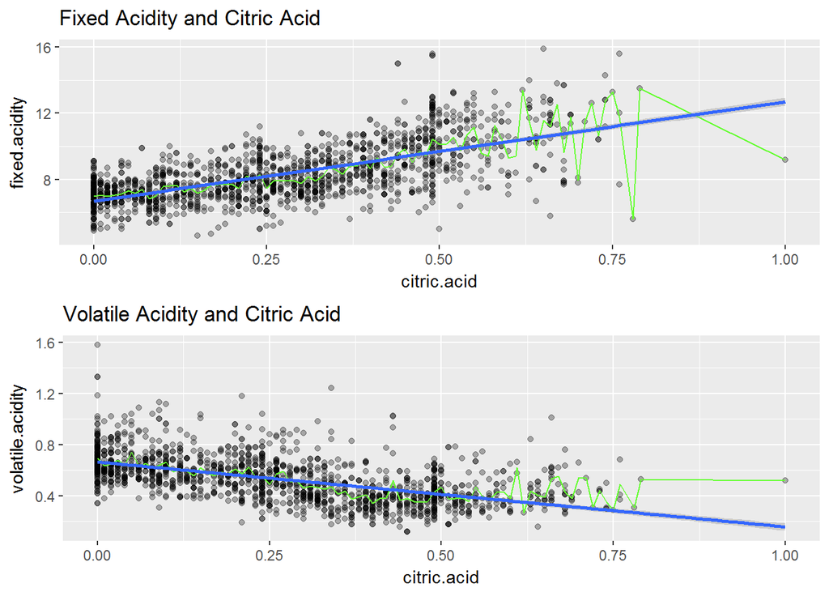

From the plot above we can see that the fixed.acidity has a positive relationship with citric.acid, and volatile.acidity has a negative relationship with citric.acid.

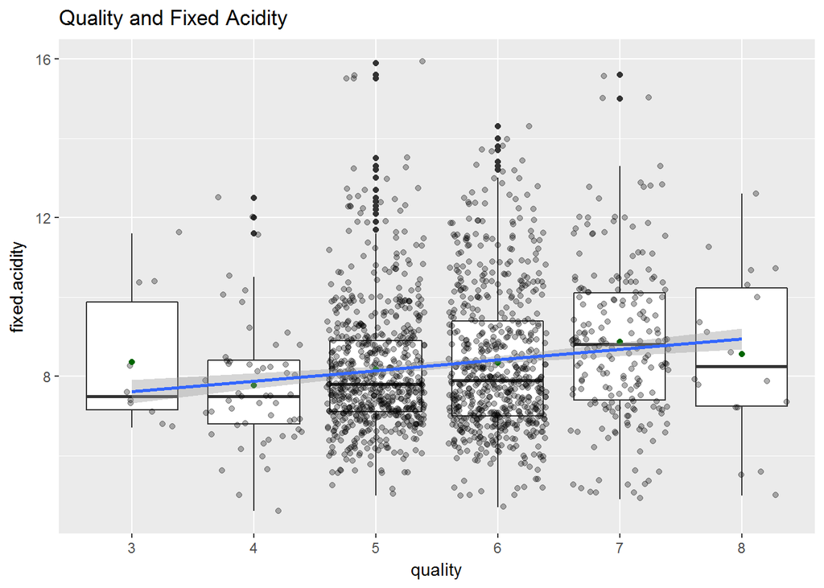

The box plot shows some relationship between the quality and fixed.acidity, but not very strong.

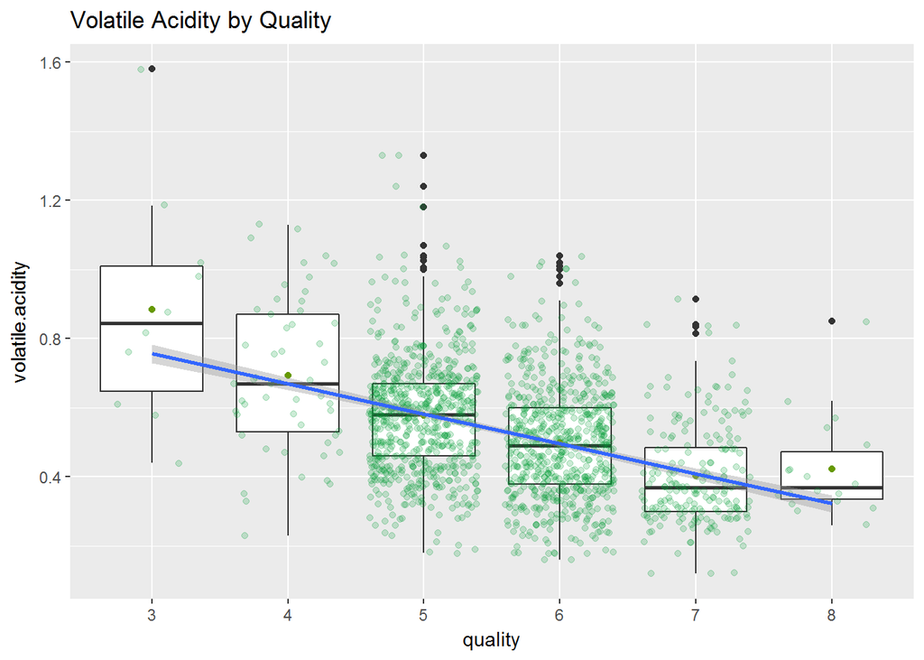

The relationship between quality and volatile acidity is clearly stronger.

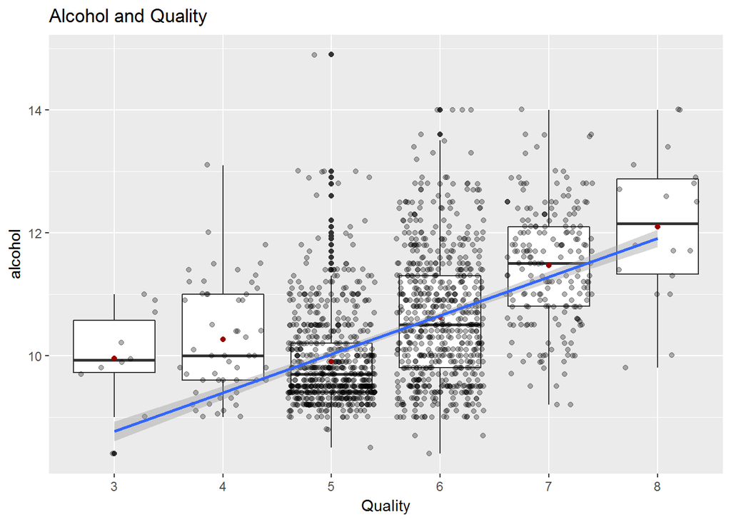

The alcohol also has a visible relationship with quality. High quality red wine often has higher degree of alcohol.